# Hearing Well-being Analysis - Main Analysis file

Note: Generative AI was used mainly as a faster form of Googling

Author

Ying Ki

Published

February 23, 2026

```python
import pandas as pd
import matplotlib.pyplot as plt
import numpy as np
from wordcloud import WordCloud

hearingcleaned = pd.read_csv("hearing_cleaned.csv")

pd.set_option("display.max_rows", None) #show all rows
pd.set_option("display.max_columns", None) #show all columns
pd.set_option("display.max_colwidth", None) #make columns wide enough

#running this code just to check dataset, but not showing on html output
hearingcleaned.describe(include='all').transpose()
#transposed to see all the columns as rows
```

## Introduction

The Hearing Wellness Survey 2025 investigates the intersection of modern auditory habits and digital health adoption. This analysis focuses on the 18–24 demographic to evaluate how prolonged personal audio use correlates with early signs of auditory strain (e.g. self-reported missing of important sounds) and the interest for mobile health interventions.

## 1 -Analysing Headphone Usage by Age

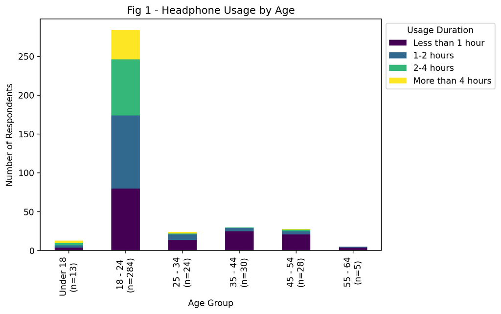

```python
age_order = ['Under 18', '18 - 24', '25 - 34', '35 - 44', '45 - 54', '55 - 64']
headphone_usage_order = ['Less than 1 hour', '1-2 hours', '2-4 hours', 'More than 4 hours']

hearingcleaned['Age_group'] = pd.Categorical(
    hearingcleaned['Age_group'],
    categories = age_order,
    ordered = True
)

hearingcleaned['Daily_Headphone_Use'] = pd.Categorical(
    hearingcleaned['Daily_Headphone_Use'],
    categories = headphone_usage_order,
    ordered = True
)
#there's 3 cells with erroneoous data for this column
#those cell will become NaNs they don't fall into the categories provided
ageheadphoneplot = hearingcleaned.dropna(subset = ['Daily_Headphone_Use'])
#Make a temporary dataframe that drops the NaN

ageheadphonect = pd.crosstab(ageheadphoneplot['Age_group'],
                 ageheadphoneplot['Daily_Headphone_Use'])
#crosstab is basically a pivot table (i.e. group + count + pivot)

fig, ax = plt.subplots(figsize=(8, 5), constrained_layout = True)

age_group_count = ageheadphoneplot['Age_group'].value_counts()
age_n_labels = [f"{age}\n(n={age_group_count.get(age,0)})" for age in age_order] #\n is escape char

ageheadphonect.plot(kind='bar', stacked = True, ax = ax, colormap = 'viridis')
ax.legend(title="Usage Duration", loc = 'upper left', bbox_to_anchor = (1.0, 1.0)) #top right outside
ax.set_xlabel("Age Group")
ax.set_ylabel("Number of Respondents")
ax.set_xticklabels(age_n_labels)
ax.set_title("Fig 1 - Headphone Usage by Age")

fig.set_constrained_layout_pads(h_pad = 0.05)
#using constrained layout and setting the padding to ensure everything is shown
plt.show()
```

From Fig.1, the ‘18–24’ age group (hereafter referred to as young adults) demonstrates a sufficiently robust sample size (n = 284) to serve as the primary analytical base. While the ‘35–44’ cohort follows with a sample size of n = 30, it was excluded from the baseline to maintain a more focused analysis.

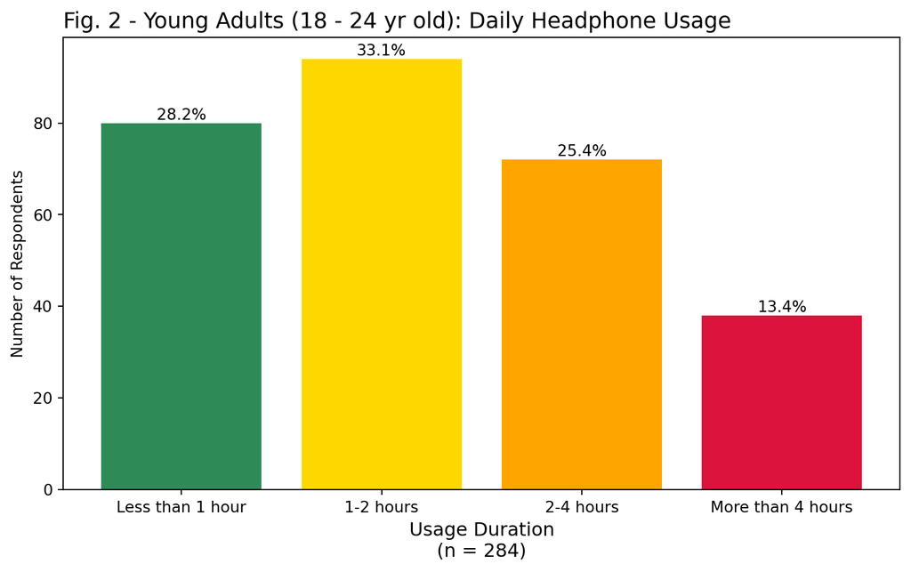

```python
young_adults_age_headphone = (
    ageheadphoneplot[ageheadphoneplot['Age_group'] == '18 - 24'] #slice
)

usage_18_24 = (
    young_adults_age_headphone['Daily_Headphone_Use']
    .value_counts()
    .reindex(headphone_usage_order)
)

def getsubpercentage(valuecount):
    total = valuecount.sum()
    return [f"{(subgroup / total * 100):.1f}%" for subgroup in valuecount]
#to get fstrings for percentage of each subgroup to 1 d.p
#creating a function because I may need later

percent_18_24 = getsubpercentage(usage_18_24)

fig, ax = plt.subplots(figsize=(8, 5), constrained_layout = True)

hp_usage_color = ['seagreen', 'gold', 'orange', 'crimson']

young_adult_hp_bar = ax.bar(usage_18_24.index, usage_18_24.values, color=hp_usage_color)
ax.bar_label(young_adult_hp_bar, labels = percent_18_24, fontsize = 10)

ax.set_title("Fig. 2 - Young Adults (18 - 24 yr old): Daily Headphone Usage", loc = 'left', fontsize = 14)
ax.set_xlabel(f"Usage Duration\n(n = 284)", fontsize = 12)
ax.set_ylabel("Number of Respondents")
plt.xticks(rotation = 0)

fig.set_constrained_layout_pads(h_pad = 0.05)
#using constrained layout and setting the padding to ensure everything is shown
plt.show()
```

Fig. 2 shows the the daily headphone usage of young adults. Most fall into the 1-2 hour range.

## 2 - Analysing Headphone Usage by Important Sounds Missed

```python
young_adults_only = hearingcleaned[hearingcleaned['Age_group'] == '18 - 24']
yesmaybeno_order = ["Yes", "Maybe", "No"] #to fix order for yes, maybe & no
yesmaybeno_colours = ["green", "steelblue", "red"]

missed_sounds_18_24_ct = (
    pd.crosstab(
    young_adults_only['Daily_Headphone_Use'],
    young_adults_only['Missed_Important_Sounds_clean']
    )
    .reindex(index = headphone_usage_order, columns = yesmaybeno_order)
)

missed_sounds_18_24_pct = missed_sounds_18_24_ct.div(missed_sounds_18_24_ct.sum(axis=1), axis=0) * 100
#normalising. divides ind celss by row total, then * 100
missed_sounds_18_24_table = (
    missed_sounds_18_24_pct.map(lambda x: f"{x:.1f}%")
    .rename_axis("Daily Usage Duration", axis = 0)
    .rename_axis("Missed Important Sounds? (self-reported general sentiments)", axis = 1)
)
#round to 1 d.p and add %
missed_sounds_18_24_table
```

| Missed Important Sounds? (self-reported general sentiments) Daily Usage Duration | Yes | Maybe | No |
| --- | --- | --- | --- |
| Less than 1 hour | 50.0% | 16.2% | 33.8% |
| 1-2 hours | 52.1% | 17.0% | 30.9% |
| 2-4 hours | 33.3% | 31.9% | 34.7% |
| More than 4 hours | 39.5% | 21.1% | 39.5% |

##### Table 1 - Headphone Usage by Important Sounds Missed (n = 284)

From Table 1, it suggests that a higher frequency usage of headphone do not increase the frequency of missing important sounds (self-reported general sentiments). In fact, there seems to be a reduced frequency of missing important sounds with higher frequency usage of headphone. Deeper analysis (e.g. Chi Square) needs to be done.

## 3 - Analysing Headphone Usage by Belief To Care For Hearing Early

```python
belief_18_24 = (
    young_adults_only.groupby('Daily_Headphone_Use', observed=False)['Belief_Early_Hearing_Care']
    #I am getting a Future Warning error for observed=False being deprecated
    .mean()
    .reindex(headphone_usage_order)
    .to_frame(name = 'Average Belief Score (1-5)')
)
#to_frame to convert a series of values into a DF for better presentation

belief_18_24
```

| Daily_Headphone_Use | Average Belief Score (1-5) |
| --- | --- |
| Less than 1 hour | 3.962500 |
| 1-2 hours | 3.702128 |
| 2-4 hours | 3.930556 |
| More than 4 hours | 4.000000 |

##### Table 2 - Headphone Usage vs. Belief for Early Hearing Care (n = 284)

From Table 2, it suggests that a higher frequency usage of headphone do not increase belief for early hearing care. We can do a one-way ANOVA to compare means (not in this report).

## 4 - Analysing interest & willingness to pay for hearing health app

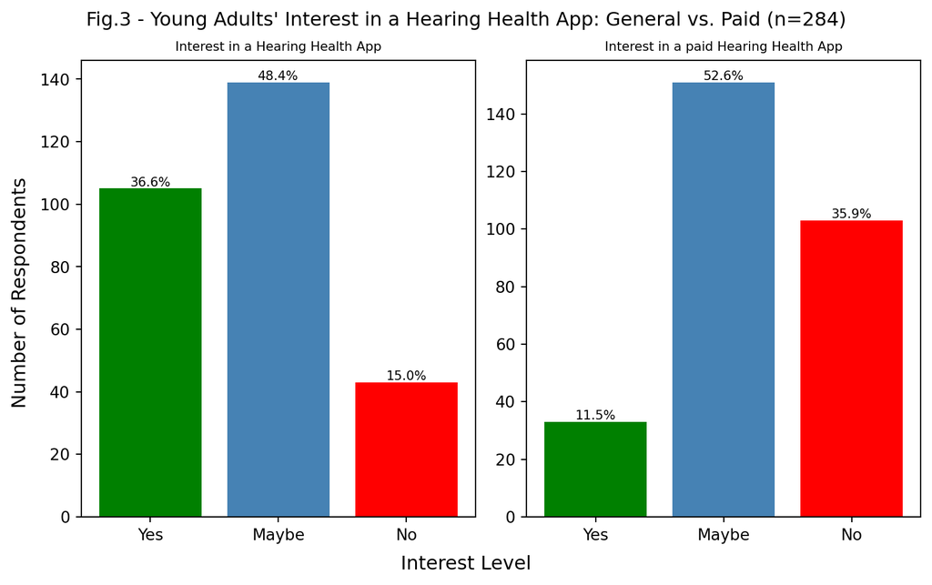

```python
yesmaybeno_order = ["Yes", "Maybe", "No"] #to fix order for yes, maybe & no
yesmaybeno_colours = ["green", "steelblue", "red"]

general_app_interest_18_24 = (
    young_adults_only['Interest_in_Hearing_App_clean']
    .value_counts()
    .reindex(yesmaybeno_order)
)
#showing code this way because code is too long
paid_app_interest_18_24 = (
    young_adults_only['Paid_App_Test_Interest_clean']
    .value_counts()
    .reindex(yesmaybeno_order)
)

general_interest_percentage = getsubpercentage(general_app_interest_18_24)
paid_interest_percentage = getsubpercentage(paid_app_interest_18_24)
#use previously defined function

fig, (ax1, ax2) = plt.subplots(1, 2, figsize = (8, 5), constrained_layout = True)

gen_bargraph = ax1.bar(
    general_app_interest_18_24.index,
    general_app_interest_18_24.values,
    color=yesmaybeno_colours
)

ax1.set_title('Interest in a Hearing Health App', fontsize = 8)
ax1.bar_label(gen_bargraph, labels=general_interest_percentage, fontsize = 8)
#ax1.set_xlabel('Interest Level', fontsize=10)
#ax1.set_ylabel('Number of Respondents', fontsize=10)

paid_bargraph = ax2.bar(
    paid_app_interest_18_24.index,
    paid_app_interest_18_24.values,
    color=yesmaybeno_colours
)

ax2.set_title('Interest in a paid Hearing Health App', fontsize = 8)
ax2.bar_label(paid_bargraph, labels=paid_interest_percentage, fontsize = 8)
#ax2.set_xlabel('Interest Level', fontsize=10)
#ax2.set_ylabel('Number of Respondents', fontsize=10)
#ax2.yaxis.set_label_position("right")

#using global labels instead, as labels are the same between the 2 graphs
fig.supxlabel("Interest Level", fontsize = 12)
fig.supylabel("Number of Respondents", fontsize = 12)
fig.suptitle("Fig.3 - Young Adults' Interest in a Hearing Health App: General vs. Paid (n=284)", fontsize = 12)

fig.set_constrained_layout_pads(h_pad = 0.05)
#using constrained layout and setting the padding to ensure everything is shown

plt.show()

#on hindsight, if I need to do more of the same graphs, I would create a function
#def plot_interest_bars(data_column, ax, title, order, color)
```

From Fig.3, while nearly 85% of young adults respondents (combined ‘Yes’ and ‘Maybe’) demonstrate initial openness to a hearing health app, interest seems highly price-sensitive. Specifically, interest drops sharply from 36.6% to 11.5% for the “Yes” group when a cost is introduced. Interestingly, the ‘Maybe’ segment remained stable at ~50%, suggesting a “wait-and-see” market that likely requires a stronger value proposition. Given the high general interest but low immediate willingness to pay, a freemium strategy (e.g. free screening with paid advanced features) is likely the most viable path for adoption.

## 5 - Analysis of Desired App Features for Hearing Health

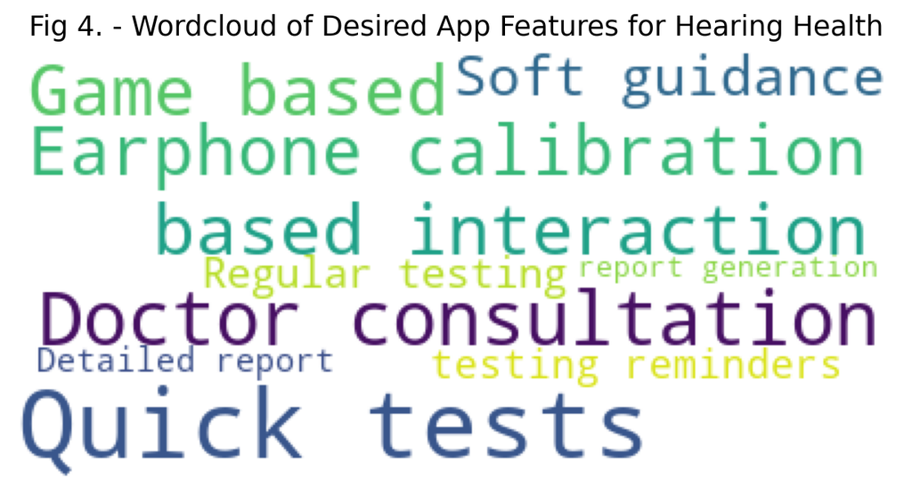

```python
desired_feature_18_24 = " ".join(young_adults_only['Desired_App_Features'])
#smashing individual responses into one massive paragraph so the Word Cloud
#wordcloud can ignore punctuations
#desired_feature_18_24 = desired_feature_18_24.replace("Game-Based Interaction", "Game Based Interaction")
#I can't seem to keep this phrase together. Marking a note here.

wordcloud_desired = WordCloud(
    collocations = True, # Keeps phrases like "Noise Cancellation" together
    background_color = "white",
    max_words = 10
    ).generate(desired_feature_18_24)
#lesser words, more emphasis on top words

plt.figure(figsize = (8, 5))
plt.imshow(wordcloud_desired) #show image for wordcloud
plt.axis("off")  # Hide x and y numbers because we are using plt
plt.title("Fig 4. - Wordcloud of Desired App Features for Hearing Health", fontsize = 14)
plt.show()
```

```python
feature_counts_dict = {} #dict for easier tally. Key + value

for row in young_adults_only['Desired_App_Features']:
    items = row.split(',')
    for item in items:
        feature_clean = item.strip().lower() #remove spcace + make lowercase
        if feature_clean in feature_counts_dict:
            feature_counts_dict[feature_clean] += 1 #add tally
        else:
            feature_counts_dict[feature_clean] = 1 #new word

sort_features = sorted(feature_counts_dict.items(), key = lambda x: x[1], reverse = True)
#sort based on value, reverse for top
top_5 = sort_features[:5]

top_5_names = [item[0].title() for item in top_5]
top_5_counts = [item[1] for item in top_5] #just the count
top_5_perc = [(count / 284) * 100 for count in top_5_counts]
top_5_table = pd.DataFrame({
    'Top 5 Features': top_5_names,
    'Mentions (n)': top_5_counts,
    'Percentage (%)': top_5_perc
})
#DF for better presentation
top_5_table
```

|  | Top 5 Features | Mentions (n) | Percentage (%) |
| --- | --- | --- | --- |
| 0 | Quick Tests | 183 | 64.436620 |
| 1 | Doctor Consultation | 143 | 50.352113 |
| 2 | Game-Based Interaction | 129 | 45.422535 |
| 3 | Earphone Calibration | 118 | 41.549296 |
| 4 | Soft Guidance | 115 | 40.492958 |

##### Table 3 - Top 5 Features

From Fig. 4, and Table 3, the most desired features is a quick hearing test, remote doctor consultation and gamified interaction.